# Statistical hypothesis testing. T-test.

Data and statistics with R Research methods

Jüri Lillemets

2019-09-18

In the following exercises you will learn how to do statistical hypothesis testig using t-test.

# 1 Load data a data set into R workspace

https://raw.githubusercontent.com/lillemets/datastatsr/master/data/kenward_cattle.csv

The data set contains repeated measurements of the weights of calves from a trial on the control of intestinal parasites. There are following variables:

- `animal`, animal factor
- `trt`, treatment factor, A or B
- `day`, day, numeric, 0-133
- `weight`, bodyweight, kg

# 2 Get an overview of the data set

See the first rows of data frame and which types of variables it contains.

```
##   animal trt day weight
## 1     A1   A   0    233
## 2     A2   A   0    231
## 3     A3   A   0    232
## 4     A4   A   0    239
## 5     A5   A   0    215
## 6     A6   A   0    236
```

```
## 'data.frame':    660 obs. of  4 variables:
##  $ animal: Factor w/ 60 levels "A1","A10","A11",..: 1 12 23 34 45 56 58 59 60 2 ...
##  $ trt   : Factor w/ 2 levels "A","B": 1 1 1 1 1 1 1 1 1 1 ...
##  $ day   : int  0 0 0 0 0 0 0 0 0 0 ...
##  $ weight: int  233 231 232 239 215 236 219 231 230 232 ...
```

Find out how many animals were measured and on which days were the measurements taken.

```
##  [1] A1  A2  A3  A4  A5  A6  A7  A8  A9  A10 A11 A12 A13 A14 A15 A16 A17
## [18] A18 A19 A20 A21 A22 A23 A24 A25 A26 A27 A28 A29 A30 A31 A32 A33 A34
## [35] A35 A36 A37 A38 A39 A40 A41 A42 A43 A44 A45 A46 A47 A48 A49 A50 A51
## [52] A52 A53 A54 A55 A56 A57 A58 A59 A60
## 60 Levels: A1 A10 A11 A12 A13 A14 A15 A16 A17 A18 A19 A2 A20 A21 ... A9
```

```
##  [1]   0  14  28  42  56  70  84  98 112 126 133
```

We can see that 60 calves were measured in the experiment. The measurements were taken every 14 days until day 126 and the last measurement was on day 133.

# 3 Understand how the measurements were taken

Use `table()` function to answer the following questions.

1. On which days was each animal measured?
2. How many measurements are there for each treatment group?
3. In which treatment group each animal belonged to?

```
##     0 14 28 42 56 70 84 98 112 126 133
## A1  1  1  1  1  1  1  1  1   1   1   1
## A10 1  1  1  1  1  1  1  1   1   1   1
## A11 1  1  1  1  1  1  1  1   1   1   1
## A12 1  1  1  1  1  1  1  1   1   1   1
## A13 1  1  1  1  1  1  1  1   1   1   1
## A14 1  1  1  1  1  1  1  1   1   1   1
```

```
##     A  B
## 0  30 30
## 14 30 30
## 28 30 30
## 42 30 30
## 56 30 30
## 70 30 30
```

```
##      A B
## A1  11 0
## A10 11 0
## A11 11 0
## A12 11 0
## A13 11 0
## A14 11 0
```

Above are the first rows of each table you should create. We can see that (1) every animal was measured once every day, (2) for each treatment group 30 measurements were taken each day, and (3) first animals in data set belong to treatment group A.

# 4 See the differences in weights by groups

First, see how the values of `weight` are distributed using a histogram.

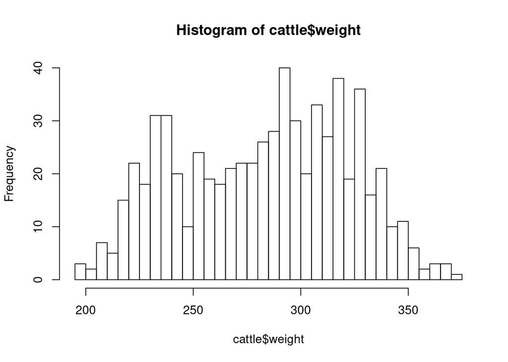

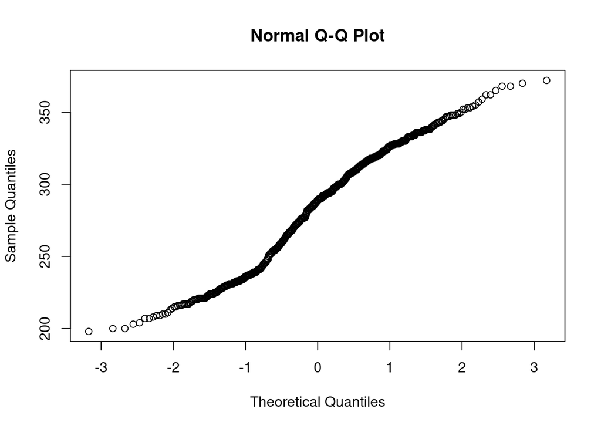

If distribution of weight values was exactly normal, the observations would follow a straight line.

See the summary statistics for weight by treatment groups. Then, create a boxplot to visualize the difference in weight between treatment groups.

```
##   trt weight.Min. weight.1st Qu. weight.Median weight.Mean weight.3rd Qu.
## 1   A    198.0000       252.0000      289.0000    284.3030       316.7500
## 2   B    200.0000       247.2500      287.0000    282.6424       315.0000
##   weight.Max.
## 1    368.0000
## 2    372.0000
```

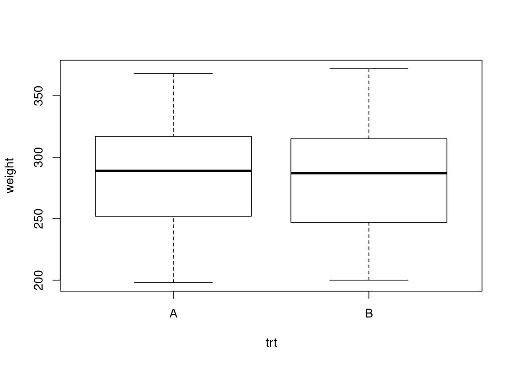

We can see that the distribution of weights is very similar for both groups.

Also create a boxplot to see the change in weight by day.

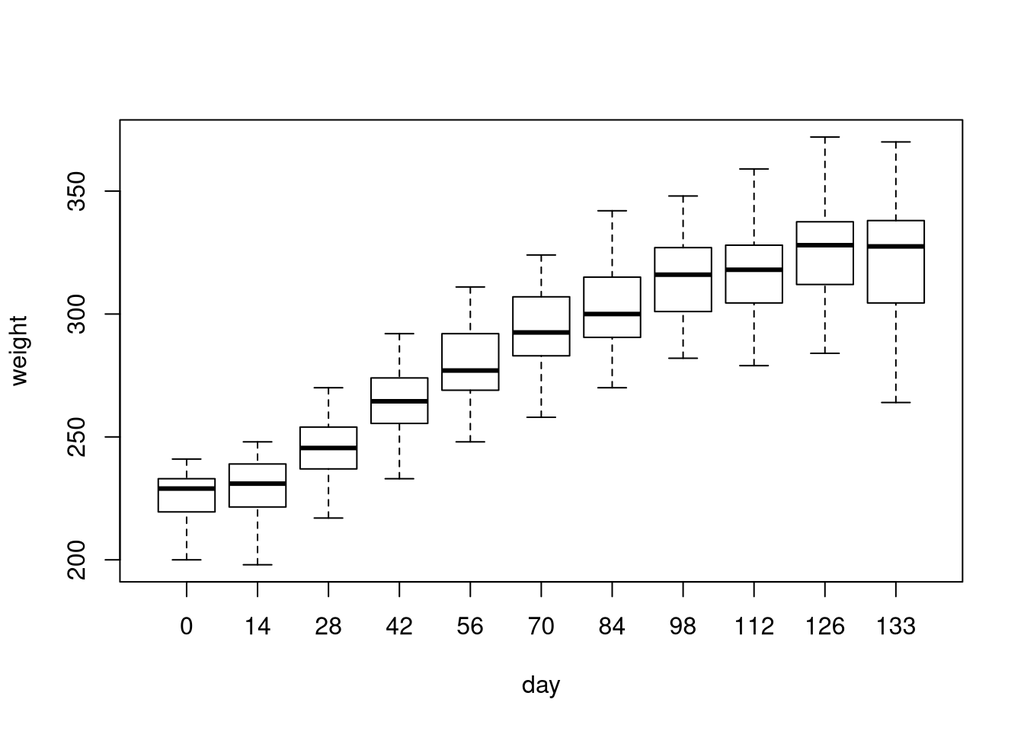

Now, add treatment groups to the plot above. To do so, the values of weight should be grouped by `trt + day`. Also, add two colors to distinguish treatment groups.

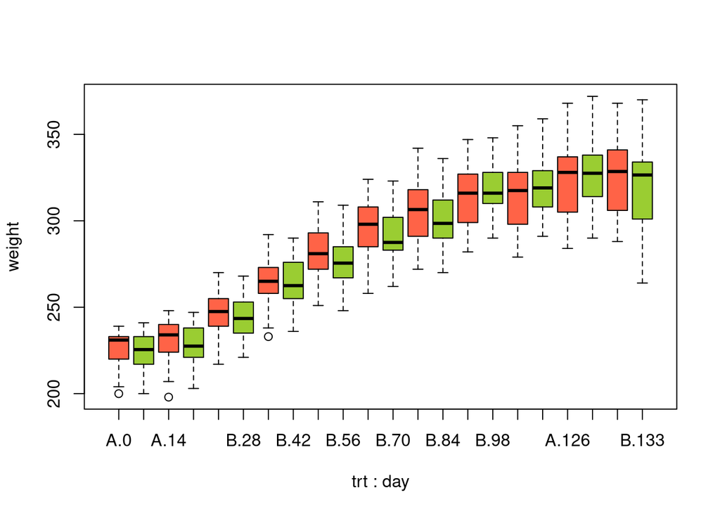

Calves in group A seem to be heavier in most days the measurements were taken.

# 5 Test differences in mean weights

You need to use function `t.test()` and subset data as needed. Interpret the results and write all of your interpretations as comments in R script file.

## 5.1 Is the true mean weight of calves in treatment group A on day 28 actually 250 kg?

```r
t.test(cattle$weight[cattle$trt == 'A' & cattle$day == 28], mu = 250)
```

```
##
##  One Sample t-test
##
## data:  cattle$weight[cattle$trt == "A" & cattle$day == 28]
## t = -1.3352, df = 29, p-value = 0.1922
## alternative hypothesis: true mean is not equal to 250
## 95 percent confidence interval:
##  242.0669 251.6664
## sample estimates:
## mean of x
##  246.8667
```

## 5.2 Is the true mean weight of calves in treatment group A on day 28 more than 240 kg?

```r
t.test(cattle$weight[cattle$trt == 'A' & cattle$day == 28], mu = 240, alternative = 'greater')
```

```
##
##  One Sample t-test
##
## data:  cattle$weight[cattle$trt == "A" & cattle$day == 28]
## t = 2.926, df = 29, p-value = 0.003304
## alternative hypothesis: true mean is greater than 240
## 95 percent confidence interval:
##  242.8792      Inf
## sample estimates:
## mean of x
##  246.8667
```

## 5.3 Are the mean weights of treatment groups actually different?

```r
t.test(weight ~ trt, cattle)
```

```
##
##  Welch Two Sample t-test
##
## data:  weight by trt
## t = 0.542, df = 657.67, p-value = 0.588
## alternative hypothesis: true difference in means is not equal to 0
## 95 percent confidence interval:
##  -4.355518  7.676730
## sample estimates:
## mean in group A mean in group B
##        284.3030        282.6424
```

## 5.4 What if we just look at the mean weigths on day 56?

```r
t.test(weight ~ trt, cattle[cattle$day %in% 56, ])
```

```
##
##  Welch Two Sample t-test
##
## data:  weight by trt
## t = 1.2079, df = 57.826, p-value = 0.232
## alternative hypothesis: true difference in means is not equal to 0
## 95 percent confidence interval:
##  -3.111191 12.577858
## sample estimates:
## mean in group A mean in group B
##        281.1667        276.4333
```

## 5.5 Are the mean weights different on day 0 and day 14?

You now compare two measurements for each calf, so you need to use a paired test.

```r
t.test(weight ~ day, cattle[cattle$day %in% 0:14, ], paired = T)
```

```
##
##  Paired t-test
##
## data:  weight by day
## t = -4.6008, df = 59, p-value = 2.281e-05
## alternative hypothesis: true difference in means is not equal to 0
## 95 percent confidence interval:
##  -5.333137 -2.100197
## sample estimates:
## mean of the differences
##               -3.716667
```

## 5.6 Are the mean weights different before and after day 70?

You first need to create a new variable (e.g. `day70`) that determines if day is more than 70 or not. Then use it as an “independent variable” in the t-test. Because you now have different number of days in each group, the test is not paired.

```r
t.test(weight ~ day70, cattle)
```

```
##
##  Welch Two Sample t-test
##
## data:  weight by day70
## t = -31.789, df = 648.98, p-value < 2.2e-16
## alternative hypothesis: true difference in means is not equal to 0
## 95 percent confidence interval:
##  -64.53024 -57.02198
## sample estimates:
## mean in group day 70 or before            mean in group later
##                       255.8472                       316.6233
```

For learning purposes, we have now done a substantial number of statistical tests and it is likely that somewhere we committed an error.

If you learn the methods in this task, you will be able to test the significance of means for the entire population if you only have a sample of it.